# Building a Deep Neural Network Step-by-Step in R

Dominic Noy

This manuscript presents the algorithm of a Deep Neural Network. I translated the code (and used some text chunks) from the Deeplearning Specialization of Deeplearning.ai on Coursera. This manuscript should support R users to comprehend the underpinnings of Neural Networks for binary classification problems. It is divided into two parts. Firstly, I present the Auxiliary Functions, which are, secondly, called within a global NN model that is applied to simulated data.

**AUXILIARY Functions**

- Initialize the parameters
- Forward propagation module
- Linear forward
- Linear Activation Forward
- Linear Model Forward
- Cost Function
- Backward propagation module
  - Linear Backward
  - Linear Activation backward
- L-Model Backward
- Update Parameters

**Deep Neural Network for Classification on Simulated Data**

- Simulate Data
- L-Layer Neural Network model
- Evaluation
  - Run the Model
  - Performance Metrics
  - Prediction

# Building a Deep Neural Network Step by Step in R - AUXILIARY Functions

- superscipt: [l] : lth layer
- superscript (i) : ith example
- lowerscipt i: ith entry in vector

## Initialize the parameters

- Linear -> relu -> linear -> sigmoid

```r
initialize_parameters <- function(layer_dims)
{

  L <- length(layer_dims)

  parameters <- vector("list", length=(L-1))

  for(l in 2:(L))
    {
    parameters[[l-1]]<-list(matrix(runif(layer_dims[l]*layer_dims[l-1]),
                                   layer_dims[l], layer_dims[l-1]),
                            matrix(runif(layer_dims[l]*1),layer_dims[l], 1))
    names(parameters[[l-1]])<-c("W", "b")
    }
  return(parameters)
}
```

## Forward propagation module

Forward propagation consist of three functions - Linear function - Linear -> Activation where Activation will be either ReLU or Sigmoid - [Linear->ReLu] x (L-1) -> Linear -> Sigmoid (whole module)
$$Z^{[l]} = W^{[l]}A^{[l-1]}+b^{[l]},$$
where $A^{[0]} = X$.

### Linear forward

```r
linear_forward <- function(A, W, b)
  {

  # Implement the linear part of a layer's forward propagation.
  #
  #   Arguments:
  #   A -- activations from previous layer (or input data):
  #   W -- weights matrix
  #   b -- bias vector
  #
  #   Returns:
  #   Z -- the input of the activation function
  #   cache -- a list containing "A", "W" and "b"

  Z <- apply(W%*%A,2, function(x) x+b)

  linear_cache <- list("A" = A, "W" = W, "b" = b)

  return(list("Z" = Z, "linear_cache" = linear_cache))
}
```

### Linear Activation Forward

- Sigmoid: $A = \sigma(Z) = \sigma(WA+b) = \frac{1}{1+e^{-(WA+b)}}$
- ReLU: $A = RELU(Z) = max(0, Z)$

the followwing linear_activation_forward function does:
$$A^{[l]} = g(Z^{[l]}) = g(W^{[l]}A^{[l-1]}+b^{[l]})$$

Output is A and cache (linear_cache, activation_cache) linear cache is $A^{[l-1]}, W^{[l]}, b^{[l]}$ activation cache is Z^{[l]}

```r
sigmoid <- function(x)
  {
  1/(1+exp(-x))
  }
```

```r
RELU <- function(x)
  {
  max(0, x)
  }
```

```r
linear_activation_forward <- function(A_prev, W, b, activation)
{
# Implement the forward propagation for the LINEAR->ACTIVATION layer#
#     Arguments
#     A_prev -- activations from previous layer (or input data)
#     W -- weights matrix
#     b -- bias vector
#     activation -- the activation to be used in this layer
#     stored as a text string: "sigmoid" or "relu"
#
#     Returns:
#     A -- the output of the activation function
#     cache -- a list containing "linear_cache" and "activation_cache"

    out <- linear_forward(A_prev, W, b)

    Z <- out$Z
    linear_cache <- out$linear_cache

    ifelse(activation=="sigmoid",
           A <- sapply(Z, function(x) sigmoid(x)),
           A <- apply(Z, 1:2, function(x) RELU(x)))

    cache <- list("linear_cache" = linear_cache, "activation_cache" = Z)

    return(list("A" = A, "cache" = cache))
}
```

### Linear Model Forward

- linear_activation_forward is repeated with RELU L-1 times
- at L, linear_activation_forward is used with sigmoid Implement:
  $$A^{[L]} = g(Z^{[L]}) = g(W^{[L]}A^{[L-1]}+b^{[L]})$$
  in a loop.

```r
L_model_forward <- function(X, parameters)
{

    # Implement forward propagation for the
    #[LINEAR->RELU]*(L-1)->LINEAR->SIGMOID computation
    #
    # Arguments:
    # X -- data of shape (input size, number of examples)
    # parameters -- output of initialize_parameters()
    #
    # Returns:
    # AL -- last post-activation value
    # caches -- list of caches containing:
    # every cache of linear_relu_forward() (there are L-1 of them, indexed from 0 to L-2)
    # the cache of linear_sigmoid_forward() (there is one, indexed L-1)


  caches <- list()
  A = X
  L = length(parameters)

#Implementation of Linear -> RELU (L-1 times); add "cache" to the "caches" list

 for(l in 1:(L-1))
 {
    A_prev <- A
    out <- linear_activation_forward(A_prev, parameters[[l]]$W, parameters[[l]]$b, "relu")
    A<-out$A
    cache <- out$cache
    caches[[l]] <- cache
 }

  A_prev <- A
  out <- linear_activation_forward(A_prev, parameters[[L]]$W, parameters[[L]]$b, "sigmoid")
  AL<-matrix(out$A, nrow=n_y)-0.001
  cache <- out$cache
  caches[[L]] <- cache

  return(list("AL" = AL, "caches" = caches))

}
```

## Cost Function

Compute the cost to find out whether the model is learning the cost is here they J:
$$-\frac{1}{m} \sum\limits_{i = 1}^{m} (y^{(i)}\log\left(a^{[L] (i)}\right) + (1-y^{(i)})\log\left(1- a^{[L](i)}\right)) \tag{7}$$

```r
compute_cost <- function(AL, Y, m)
{
  # Implement the cost function
  #   Arguments:
  #   AL -- probability vector corresponding to your label predictions
  #   Y -- true "label" vector
  #
  #   Returns:
  #   cost -- cross-entropy cost

  m <- length(Y)

  #Computer loss from AL and y
  cost <- - (1/m)*sum(Y*log(abs(AL))+(1-Y)*log(abs(1-AL)))
  return(cost)
}
```

## Backward propagation module

Back propagation is applied in order to obtain the gradient of the loss (cost) function with respect to the parameters I built three functions: - Linear backward - linear -> Activation backward where activation computes the derivative of either the ReLU or sigmoid - the entire backward model: linear -> ReLu * L-1 -> Linear -> Sigmoid

### Linear Backward

For layer l, the linear part is: $Z^{[l]} = W^{[l]}A^{[l-1]}+b^{[l]}$ folloId by activation I have: derivative: $dZ^{[l]}= \frac{\partial \mathcal{L}}{\partial Z^{[l]}}$ goal: get $dW^{[l]}, db^{[l]}, dA^{[l-1]}$ by:
$$dW^{[l]} = \frac{\partial \mathcal{L}}{\partial W^{[l]}}=\frac{1}{m}dZ^{[l]}A^{[l-1]T}$$
$$db^{[l]} = \frac{\partial \mathcal{L}}{\partial b^{[l]}}=\frac{1}{m}\sum_{i=1}^mdZ^{[l](i)}\\$$
$$dA^{[l-1]}=\frac{\partial \mathcal{L}}{\partial A^{[l-1]}}=W^{[l]T}dZ^{[l]}$$

```r
linear_backward <- function(dZ, linear_cache)
  {
  # Implement the linear portion of backward
  #propagation for a single layer (layer l)
  #
  #   Arguments:
  #   dZ -- Gradient of the cost with respect to the linear output
  #   cache -- tuple of values (A_prev, W, b) coming from the forward propagation in the current layer
  #
  #   Returns:
  #   dA_prev -- Gradient of the cost with respect
  #to the activation (of the previous layer l-1)
  #   dW -- Gradient of the cost with respect to W (current layer l)
  #   db -- Gradient of the cost with respect to b (current layer l)

  #linear_cache$A is A_prev compared to the other parameters
  A_prev <- linear_cache$A
  W <- linear_cache$W
  b <- linear_cache$b

  m <- dim(A_prev)[2]

  dW <- (dZ%*%t(A_prev))/m
  db <- as.matrix(rowSums(dZ)/m)

  dA_prev = t(W)%*%matrix(dZ, nrow=ncol(t(W)))
  return(list("dA_prev"=dA_prev, "dW"=dW, "db"=db))
}
```

### Linear Activation backward

- sigmoid_backward: backward propagation of SIGMOID
- relu_backward: relu_backward(dA, activation_cache)

g(.) is activation, g’(.) is backward:
$$dZ^{[l]} = dA[l]g'(Z^{[l]})$$
$$\frac{d}{dx}\sigma(x) = \sigma(x)(1-\sigma(x))$$

```r
sigmoid_backward<-function(x){sigmoid(x)*(1 - sigmoid(x))}
```

```r
RELU_backward<-function(x){ifelse(x > 0, 1, 0)}
```

```r
linear_activation_backward<-function(dA, cache, activation)
{
# Implement the backward propagation for the LINEAR->ACTIVATION layer.
#
#     Arguments:
#     dA -- post-activation gradient for current layer l
#     cache -- tuple of values (linear_cache, activation_cache) I store for
#     computing backward propagation efficiently
#     activation -- the activation to be used in this layer,
#     stored as a text string: "sigmoid" or "relu"
#
#     Returns:
#     dA_prev -- Gradient of the cost with respect to the activation
#     (of the previous layer l-1)
#     dW -- Gradient of the cost with respect to W (current layer l)
#     db -- Gradient of the cost with respect to b (current layer l)

  linear_cache <- cache$linear_cache
  activation_cache <- cache$activation_cache
  ifelse(activation=="relu",
         dZ <- dA*RELU_backward(activation_cache),
         dZ <- dA*sigmoid_backward(activation_cache))

  output<-linear_backward(dZ, linear_cache)
  return(output)
}
```

## L-Model Backward

In forward propagation (L_model_forward) stored cache (X, W, b, z) Now, L_model_backward uses this cache by iterating through all hidden layers backward, starting at layer L.

1. Initialize backpropagation: I have:
   $$A^{[L]} = \sigma(Z^{[L]})$$
   compute:
   $$dA^{[L]} = \frac{\partial \mathcal{L}}{\partial A^{[L]}}=-(\frac{Y}{AL}-\frac{1-Y}{1-AL})$$
2. Fed $dA^{[L]}$ into LINEAR -> SIGMOID (use cache from L_model_forward)
3. loop through LINEAR->RELU_backward
4. store dA, dW, db

```r
L_model_backward<-function(AL, Y, caches)
{
    # Implement the backward propagation for the
    # [LINEAR->RELU] * (L-1) -> LINEAR -> SIGMOID
    #
    #     Arguments:
    #     AL -- probability vector, output of the forward
    #     propagation (L_model_forward())
    #     Y -- true "label" vector
    #     caches -- list of caches containing:
    #     every cache of linear_activation_forward() with "relu"
    #     (it's caches[l], for l in range(L-1) i.e l = 0...L-2)
    #     the cache of linear_activation_forward() with "sigmoid"
    #     (it's caches[L-1])
    #
    #     Returns:
    #     grads -- A list with the gradients

    caches_back<-caches
    grads <- list()
    L <- length(caches_back) #number of caches
    m <- dim(AL)[2]

    #Initializing the backpropagation
    dAL <- - ((Y/AL) - ((1-Y)/(1-AL)))

    #Lth layer (Sigmoid -> Linear) gradients
    output<-linear_activation_backward(dAL,
                                       caches_back[L][[1]],
                                       activation="sigmoid")
    #start with cache at Layer L

    grads[[L]]<-output

    ###loop over the relu->linear
    for(l in (L-1):1)
      {
      grads[[l]]<-linear_activation_backward(
        grads[[l+1]]$dA_prev,
        caches_back[l][[1]], activation="relu")
      }
    return(grads)
}
```

## Update Parameters

Updating parameters using gradient descent
$$W^{[l]} = W^{[L]}-\alpha dW^{[l]}$$
$$b^{[l]} = b^{[L]}-\alpha db^{[l]}$$

```r
update_parameters<-function(parameters, grads, learning_rate)
{
  # Update parameters using gradient descent
  L <- length(parameters)

  for(l in 1:L)
  {
    parameters[[l]]$W <- parameters[[l]]$W - learning_rate*grads[[l]]$dW
    parameters[[l]]$b <- parameters[[l]]$b - learning_rate*grads[[l]]$db
  }
 return(parameters)
}
```

# Deep Neural Network for Classification: Application

## Simulate Data

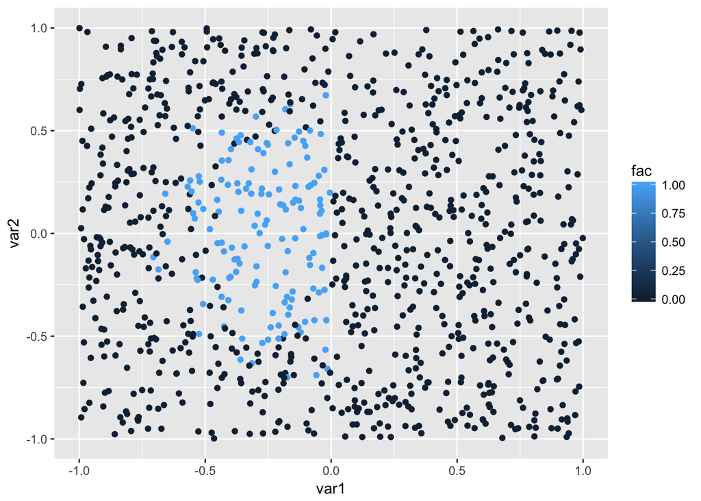

```r
set.seed(123)
#for illustration purpose, I use two features
n_features<-2
#number of observations
m<-1000

X<-matrix(runif(n_features*m, -1,1), ncol=n_features, nrow=m)
y<-rep(NA, m)

#create some weired function
r<-0.5
#create circle
d = sqrt(X[,1]^2 + X[,2]^2)+rnorm(m, -0.1,0.1)
y[d<r]<-1
y[d>=r]<-0
#cut part of the circle
y[X[,1]>0]<-0


#visualize first two variables
plt<-data.frame(cbind(X, y))
names(plt)<-c("var1", "var2", "fac")
require(ggplot2)
ggplot(plt, aes(x=var1, y=var2, col=fac))+
  geom_point()
```

```r
#reshape arrays
X<-t(X)
y<-matrix(y, nrow=1)
```

## Split into Training and Testset

```r
#split into training and test set
prop_training <- 0.7
train_index<-sample(c(1:prop_training*m), prop_training*m, replace=FALSE)
X_train <- X[,train_index]
X_test <- X[,-train_index]
y_train<-y[,train_index]
y_test<-y[,-train_index]
```

## L-Layer Neural Network model

used the helper functions to build the L-Layer neural network with the structure: [LINEAR -> RELU]*(L-1) -> LINEAR -> SIGMOID

```r
L_layer_model<- function(X, Y, layers_dims, learning_rate,  print_cost=FALSE, num_iteration)
  {

  cost <- list()

  #Parameter initialization
  parameters <- initialize_parameters(layers_dims)

  #for loop
  costs<-c()
  for(i in 1:num_iteration)
    {
        #Forward Propagation: [Linear -> Relu]*(L-1) -> Linear -> Sigmoid
        out <- L_model_forward(X, parameters)
        AL <- out$AL
        caches <- out$caches

        #Compute costs
        cost <- compute_cost(AL, Y, length(Y))

        #Backward Propagation
        grads <- L_model_backward(AL, Y, caches)

        #Update parameters
        parameters <- update_parameters(parameters, grads, learning_rate)

        #cost
        #print costs
        if(print_cost==TRUE & i%%100 == 0){print(cost)}
        costs[i]<-cost

        if(cost<=0){break}
    }
  return(list(costs,parameters))
}
```

## Evaluation

### Run the Model

```r
#out[[1]] = costs
#out[[2]] = paramters for prediction
n_x <- n_features #number of features (of X)
n_h <- 3 #n of nodes in layer h
n_y <- 1 #label (cat or no cat)
layers_dims = c(n_x, n_h, n_h, n_h, n_y)

out <- L_layer_model(X_train, y_train, layers_dims,
                     num_iteration=1000,print_cost=TRUE,
                     learning_rate=0.1)
```

```
## [1] 0.3727014
## [1] 0.3542696
## [1] 0.3332908
## [1] 0.3037804
## [1] 0.2602345
## [1] 0.2082229
## [1] 0.1711378
## [1] 0.1490095
## [1] 0.1400057
## [1] 0.1350756
```

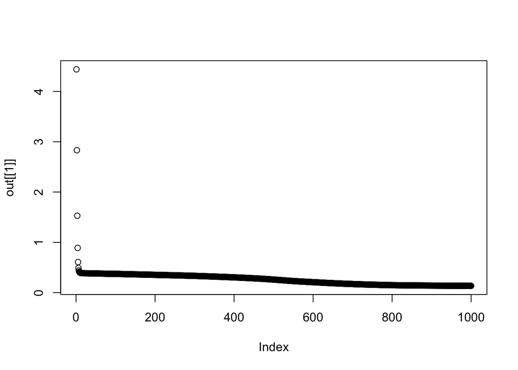

```r
plot(out[[1]])
```

# Performance Metrics

```r
pred <- L_model_forward(X_test, out[[2]])

y_hat<-pred$AL
y_hat[y_hat<=0.5]<-0
y_hat[y_hat>0.5]<-1
#y hat

#accuracy
list(
"accuracy"=sum(y_hat==y_test)/length(y_test),
"precision"=sum(y_hat==1 & y_test==1)/ sum((y_hat==1 & y_test==1)|(y_test==1 & y_hat==0)),
"recall"=sum(y_hat==1 & y_test==1)/ sum((y_hat==1 & y_test==1)|(y_test==0 & y_hat==1)),
"specificity"= 1-sum(y_hat==1 & y_test==0)/sum((y_hat==1 & y_test==0)|(y_hat==0 & y_test==0)))
```

```
## $accuracy
## [1] 0.93
##
## $precision
## [1] 0.6875
##
## $recall
## [1] 0.8461538
##
## $specificity
## [1] 0.9761905
```

# Prediction

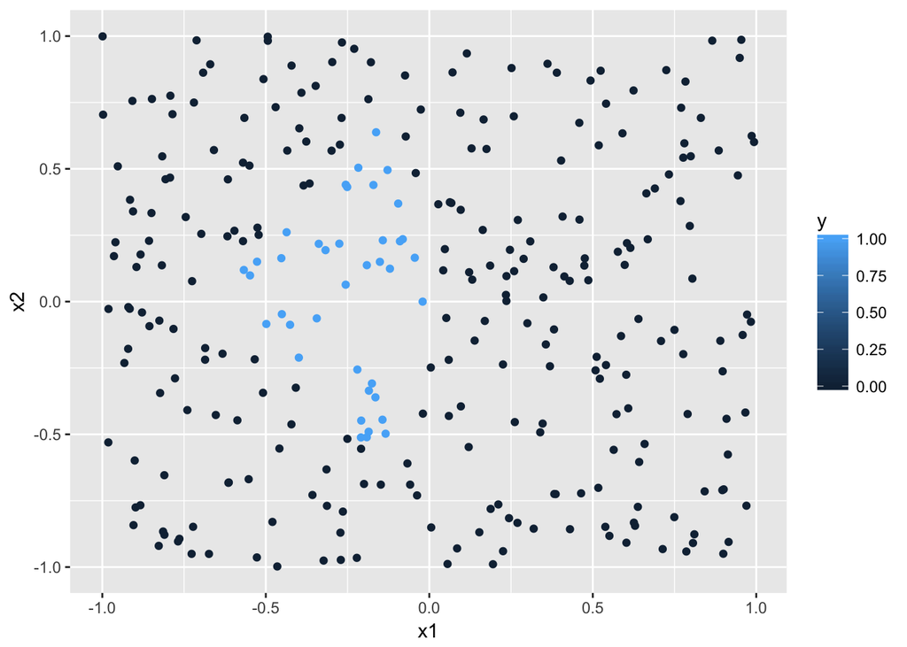

```r
test<-data.frame(cbind(t(X_test), t(y_hat)))
names(test) <- c("x1", "x2", "y")
ggplot(test, aes(x=x1, y=x2, col=y))+
  geom_point()
```